# examples_1203

Consider the following product of linear binomials:

$$({-2}x-{8})({-2}x+{7})$$

When the expression is expanded and like terms are combined, an equivalent expression can be expressed in standard form:

$$ax^2+bx+c$$

where $a$, $b$, and $c$ are integers.

- What is the value of $c$?

You could use the box method.

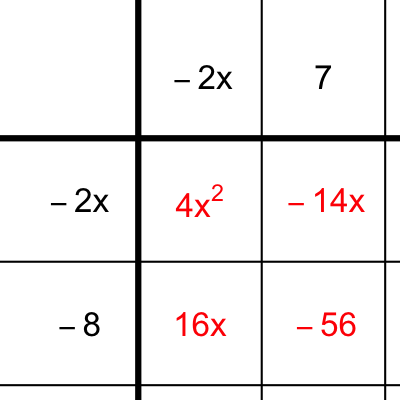

Or, you can FOIL...

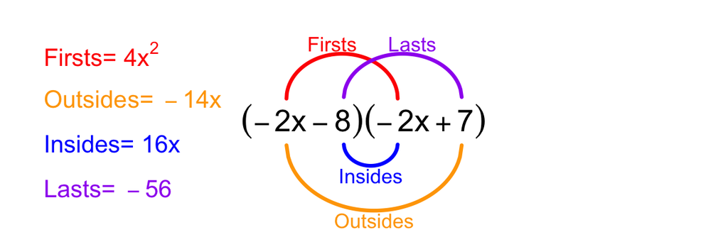

Either way, you should first get
$${4}x^{2}-{14}x+{16}x-{56}$$

And, after combining like terms, you should get
$${4}x^{2}+{2}x-{56}$$

Thus, $a=4$ and $b=2$ and $c=-56$. This question specifically asked for the value of $c$, so the answer is $-56$.

Consider the following product of linear binomials:

$$({-7}x+{5})({4}x+{3})$$

When the expression is expanded and like terms are combined, an equivalent expression can be expressed in standard form:

$$ax^2+bx+c$$

where $a$, $b$, and $c$ are integers.

- What is the value of $c$?

You could use the box method.

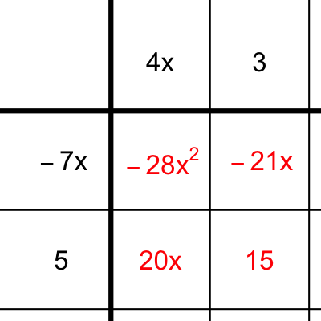

Or, you can FOIL...

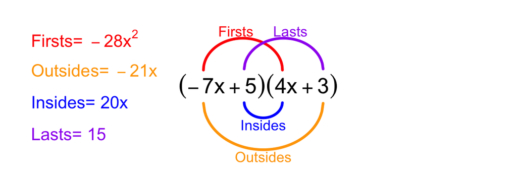

Either way, you should first get
$${-28}x^{2}-{21}x+{20}x+{15}$$

And, after combining like terms, you should get
$${-28}x^{2}-x+{15}$$

Thus, $a=-28$ and $b=-1$ and $c=15$. This question specifically asked for the value of $c$, so the answer is $15$.

Consider the following product of linear binomials:

$$({8}x+{1})({-8}x-{2})$$

When the expression is expanded and like terms are combined, an equivalent expression can be expressed in standard form:

$$ax^2+bx+c$$

where $a$, $b$, and $c$ are integers.

- What is the value of $c$?

You could use the box method.

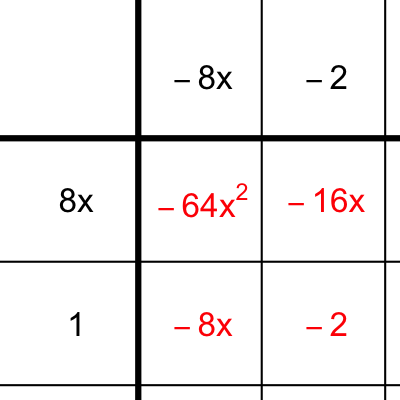

Or, you can FOIL...

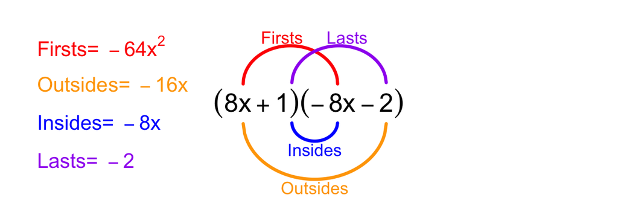

Either way, you should first get
$${-64}x^{2}-{16}x-{8}x-{2}$$

And, after combining like terms, you should get
$${-64}x^{2}-{24}x-{2}$$

Thus, $a=-64$ and $b=-24$ and $c=-2$. This question specifically asked for the value of $c$, so the answer is $-2$.

Consider the following product of linear binomials:

$$({-6}x+{6})({-3}x-{6})$$

When the expression is expanded and like terms are combined, an equivalent expression can be expressed in standard form:

$$ax^2+bx+c$$

where $a$, $b$, and $c$ are integers.

- What is the value of $c$?

You could use the box method.

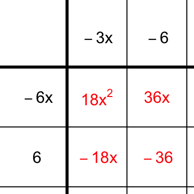

Or, you can FOIL...

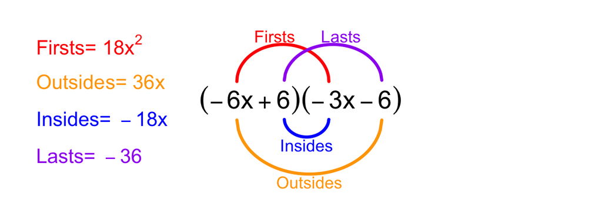

Either way, you should first get
$${18}x^{2}+{36}x-{18}x-{36}$$

And, after combining like terms, you should get
$${18}x^{2}+{18}x-{36}$$

Thus, $a=18$ and $b=18$ and $c=-36$. This question specifically asked for the value of $c$, so the answer is $-36$.

Consider the following product of linear binomials:

$$({-4}x-{7})({4}x-{4})$$

When the expression is expanded and like terms are combined, an equivalent expression can be expressed in standard form:

$$ax^2+bx+c$$

where $a$, $b$, and $c$ are integers.

- What is the value of $c$?

You could use the box method.

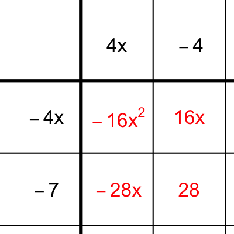

Or, you can FOIL...

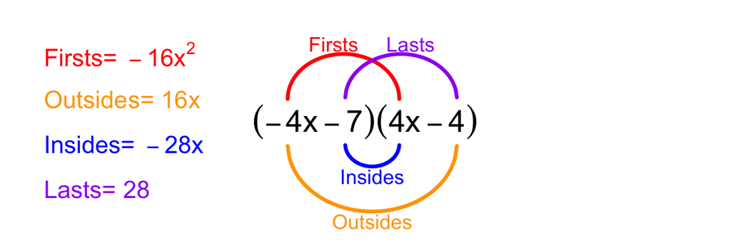

Either way, you should first get
$${-16}x^{2}+{16}x-{28}x+{28}$$

And, after combining like terms, you should get
$${-16}x^{2}-{12}x+{28}$$

Thus, $a=-16$ and $b=-12$ and $c=28$. This question specifically asked for the value of $c$, so the answer is $28$.

Consider the following product of linear binomials:

$$({7}x-{4})({-3}x-{1})$$

When the expression is expanded and like terms are combined, an equivalent expression can be expressed in standard form:

$$ax^2+bx+c$$

where $a$, $b$, and $c$ are integers.

- What is the value of $c$?

You could use the box method.

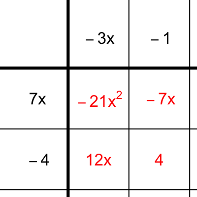

Or, you can FOIL...

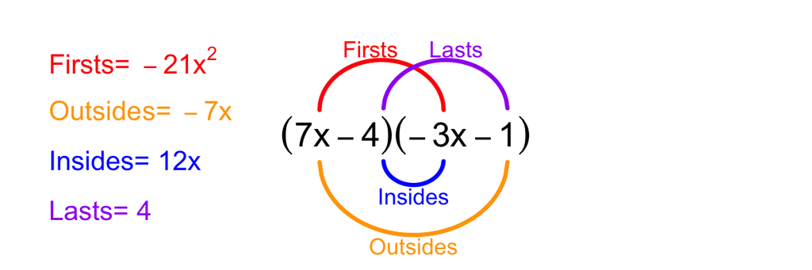

Either way, you should first get
$${-21}x^{2}-{7}x+{12}x+{4}$$

And, after combining like terms, you should get
$${-21}x^{2}+{5}x+{4}$$

Thus, $a=-21$ and $b=5$ and $c=4$. This question specifically asked for the value of $c$, so the answer is $4$.

Consider the following product of linear binomials:

$$({-2}x+{9})({-9}x-{2})$$

When the expression is expanded and like terms are combined, an equivalent expression can be expressed in standard form:

$$ax^2+bx+c$$

where $a$, $b$, and $c$ are integers.

- What is the value of $c$?

You could use the box method.

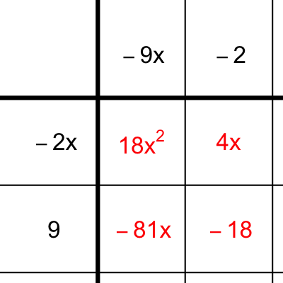

Or, you can FOIL...

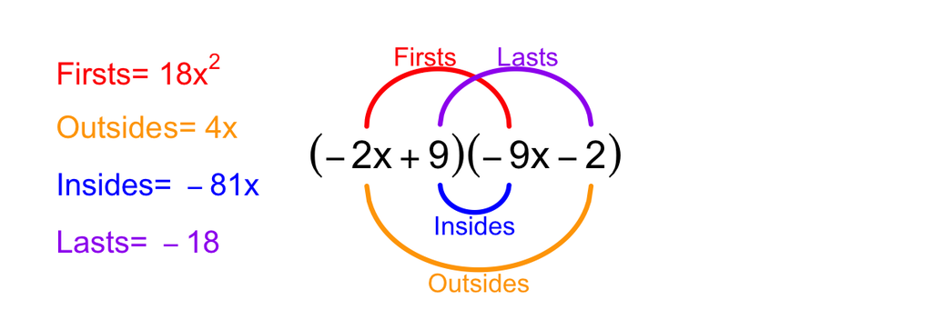

Either way, you should first get
$${18}x^{2}+{4}x-{81}x-{18}$$

And, after combining like terms, you should get
$${18}x^{2}-{77}x-{18}$$

Thus, $a=18$ and $b=-77$ and $c=-18$. This question specifically asked for the value of $c$, so the answer is $-18$.

Consider the following product of linear binomials:

$$({-9}x+{7})({-9}x-{9})$$

When the expression is expanded and like terms are combined, an equivalent expression can be expressed in standard form:

$$ax^2+bx+c$$

where $a$, $b$, and $c$ are integers.

- What is the value of $c$?

You could use the box method.

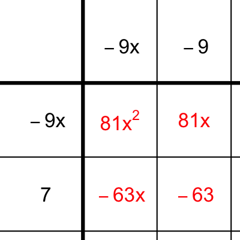

Or, you can FOIL...

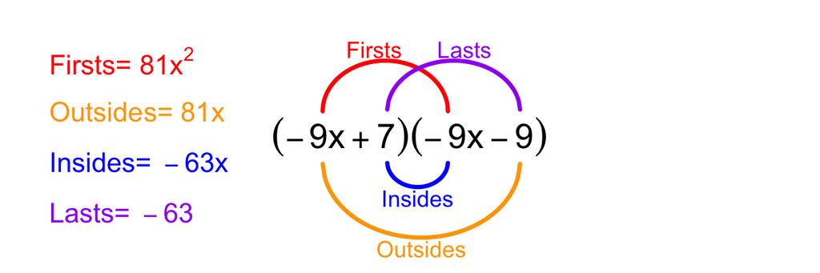

Either way, you should first get
$${81}x^{2}+{81}x-{63}x-{63}$$

And, after combining like terms, you should get
$${81}x^{2}+{18}x-{63}$$

Thus, $a=81$ and $b=18$ and $c=-63$. This question specifically asked for the value of $c$, so the answer is $-63$.

The quadratic polynomial $p(x)$ is defined below.

$$p(x)~=~x^{2}+{3}x-{54}$$

Which two linear polynomials are factors of $p(x)$?

$x-{12}$$x-{11}$$x-{10}$$x-{9}$$x-{8}$$x-{7}$$x-{6}$$x-{5}$$x-{4}$$x-{3}$$x-{2}$$x-{1}$$x+{1}$$x+{2}$$x+{3}$$x+{4}$$x+{5}$$x+{6}$$x+{7}$$x+{8}$$x+{9}$$x+{10}$$x+{11}$$x+{12}$

You can get this by guessing and checking. Eventually you might guess the following:

$$p(x) ~=~
(x-{6})\cdot(x+{9})$$

You can check by using polynomial multiplication (in this case you can use the [FOIL method](https://en.wikipedia.org/wiki/FOIL_method)).

| * | $x$ | $-6$ |
| --- | --- | --- |
| $x$ | $x^2$ | ${-6}x$ |
| $9$ | ${9}x$ | $-54$ |

$$p(x) ~=~
x^{2}-{6}x+{9}x-{54}$$

$$p(x) ~=~ x^{2}+{3}x-{54}$$

After you've done this a few hundred times, you'll notice that you wanted two numbers that added to give 3 and multiplied to give -54. So, you start thinking of factor pairs of -54 until you find a pair that sums to 3. You will see that below I've listed all factor pairs of -54, along with the corresponding polynomials in factored and expanded forms.

| Factor pairs of -54 | Factored polynomial | Expanded polynomial |
| --- | --- | --- |
| 1 and -54 | $(x+{1})\cdot (x-{54})$ | $x^{2}-{53}x-{54}$ |
| -1 and 54 | $(x-{1})\cdot (x+{54})$ | $x^{2}+{53}x-{54}$ |
| 2 and -27 | $(x+{2})\cdot (x-{27})$ | $x^{2}-{25}x-{54}$ |
| -2 and 27 | $(x-{2})\cdot (x+{27})$ | $x^{2}+{25}x-{54}$ |
| 3 and -18 | $(x+{3})\cdot (x-{18})$ | $x^{2}-{15}x-{54}$ |
| -3 and 18 | $(x-{3})\cdot (x+{18})$ | $x^{2}+{15}x-{54}$ |
| 6 and -9 | $(x+{6})\cdot (x-{9})$ | $x^{2}-{3}x-{54}$ |
| -6 and 9 | $(x-{6})\cdot (x+{9})$ | $x^{2}+{3}x-{54}$ |

And, so, $x^{2}+{3}x-{54}$ is an equivalent expression to $(x-{6})\cdot(x+{9})$, which is also equivalent to $(x+{9})\cdot(x-{6})$.

The quadratic polynomial $p(x)$ is defined below.

$$p(x)~=~x^{2}-{11}x+{28}$$

Which two linear polynomials are factors of $p(x)$?

$x-{12}$$x-{11}$$x-{10}$$x-{9}$$x-{8}$$x-{7}$$x-{6}$$x-{5}$$x-{4}$$x-{3}$$x-{2}$$x-{1}$$x+{1}$$x+{2}$$x+{3}$$x+{4}$$x+{5}$$x+{6}$$x+{7}$$x+{8}$$x+{9}$$x+{10}$$x+{11}$$x+{12}$

You can get this by guessing and checking. Eventually you might guess the following:

$$p(x) ~=~
(x-{4})\cdot(x-{7})$$

You can check by using polynomial multiplication (in this case you can use the [FOIL method](https://en.wikipedia.org/wiki/FOIL_method)).

| * | $x$ | $-4$ |
| --- | --- | --- |
| $x$ | $x^2$ | ${-4}x$ |
| $-7$ | ${-7}x$ | $28$ |

$$p(x) ~=~
x^{2}-{4}x-{7}x+{28}$$

$$p(x) ~=~ x^{2}-{11}x+{28}$$

After you've done this a few hundred times, you'll notice that you wanted two numbers that added to give -11 and multiplied to give 28. So, you start thinking of factor pairs of 28 until you find a pair that sums to -11. You will see that below I've listed all factor pairs of 28, along with the corresponding polynomials in factored and expanded forms.

| Factor pairs of 28 | Factored polynomial | Expanded polynomial |
| --- | --- | --- |
| 1 and 28 | $(x+{1})\cdot (x+{28})$ | $x^{2}+{29}x+{28}$ |
| -1 and -28 | $(x-{1})\cdot (x-{28})$ | $x^{2}-{29}x+{28}$ |
| 2 and 14 | $(x+{2})\cdot (x+{14})$ | $x^{2}+{16}x+{28}$ |
| -2 and -14 | $(x-{2})\cdot (x-{14})$ | $x^{2}-{16}x+{28}$ |
| 4 and 7 | $(x+{4})\cdot (x+{7})$ | $x^{2}+{11}x+{28}$ |
| -4 and -7 | $(x-{4})\cdot (x-{7})$ | $x^{2}-{11}x+{28}$ |

And, so, $x^{2}-{11}x+{28}$ is an equivalent expression to $(x-{4})\cdot(x-{7})$, which is also equivalent to $(x-{7})\cdot(x-{4})$.

The quadratic polynomial $p(x)$ is defined below.

$$p(x)~=~x^{2}+{17}x+{60}$$

Which two linear polynomials are factors of $p(x)$?

$x-{12}$$x-{11}$$x-{10}$$x-{9}$$x-{8}$$x-{7}$$x-{6}$$x-{5}$$x-{4}$$x-{3}$$x-{2}$$x-{1}$$x+{1}$$x+{2}$$x+{3}$$x+{4}$$x+{5}$$x+{6}$$x+{7}$$x+{8}$$x+{9}$$x+{10}$$x+{11}$$x+{12}$

You can get this by guessing and checking. Eventually you might guess the following:

$$p(x) ~=~
(x+{12})\cdot(x+{5})$$

You can check by using polynomial multiplication (in this case you can use the [FOIL method](https://en.wikipedia.org/wiki/FOIL_method)).

| * | $x$ | $12$ |
| --- | --- | --- |
| $x$ | $x^2$ | ${12}x$ |
| $5$ | ${5}x$ | $60$ |

$$p(x) ~=~
x^{2}+{12}x+{5}x+{60}$$

$$p(x) ~=~ x^{2}+{17}x+{60}$$

After you've done this a few hundred times, you'll notice that you wanted two numbers that added to give 17 and multiplied to give 60. So, you start thinking of factor pairs of 60 until you find a pair that sums to 17. You will see that below I've listed all factor pairs of 60, along with the corresponding polynomials in factored and expanded forms.

| Factor pairs of 60 | Factored polynomial | Expanded polynomial |
| --- | --- | --- |
| 1 and 60 | $(x+{1})\cdot (x+{60})$ | $x^{2}+{61}x+{60}$ |
| -1 and -60 | $(x-{1})\cdot (x-{60})$ | $x^{2}-{61}x+{60}$ |
| 2 and 30 | $(x+{2})\cdot (x+{30})$ | $x^{2}+{32}x+{60}$ |
| -2 and -30 | $(x-{2})\cdot (x-{30})$ | $x^{2}-{32}x+{60}$ |
| 3 and 20 | $(x+{3})\cdot (x+{20})$ | $x^{2}+{23}x+{60}$ |
| -3 and -20 | $(x-{3})\cdot (x-{20})$ | $x^{2}-{23}x+{60}$ |
| 4 and 15 | $(x+{4})\cdot (x+{15})$ | $x^{2}+{19}x+{60}$ |
| -4 and -15 | $(x-{4})\cdot (x-{15})$ | $x^{2}-{19}x+{60}$ |
| 5 and 12 | $(x+{5})\cdot (x+{12})$ | $x^{2}+{17}x+{60}$ |
| -5 and -12 | $(x-{5})\cdot (x-{12})$ | $x^{2}-{17}x+{60}$ |
| 6 and 10 | $(x+{6})\cdot (x+{10})$ | $x^{2}+{16}x+{60}$ |
| -6 and -10 | $(x-{6})\cdot (x-{10})$ | $x^{2}-{16}x+{60}$ |

And, so, $x^{2}+{17}x+{60}$ is an equivalent expression to $(x+{12})\cdot(x+{5})$, which is also equivalent to $(x+{5})\cdot(x+{12})$.

The quadratic polynomial $p(x)$ is defined below.

$$p(x)~=~x^{2}+{9}x-{22}$$

Which two linear polynomials are factors of $p(x)$?

$x-{12}$$x-{11}$$x-{10}$$x-{9}$$x-{8}$$x-{7}$$x-{6}$$x-{5}$$x-{4}$$x-{3}$$x-{2}$$x-{1}$$x+{1}$$x+{2}$$x+{3}$$x+{4}$$x+{5}$$x+{6}$$x+{7}$$x+{8}$$x+{9}$$x+{10}$$x+{11}$$x+{12}$

You can get this by guessing and checking. Eventually you might guess the following:

$$p(x) ~=~
(x+{11})\cdot(x-{2})$$

You can check by using polynomial multiplication (in this case you can use the [FOIL method](https://en.wikipedia.org/wiki/FOIL_method)).

| * | $x$ | $11$ |
| --- | --- | --- |
| $x$ | $x^2$ | ${11}x$ |
| $-2$ | ${-2}x$ | $-22$ |

$$p(x) ~=~
x^{2}+{11}x-{2}x-{22}$$

$$p(x) ~=~ x^{2}+{9}x-{22}$$

After you've done this a few hundred times, you'll notice that you wanted two numbers that added to give 9 and multiplied to give -22. So, you start thinking of factor pairs of -22 until you find a pair that sums to 9. You will see that below I've listed all factor pairs of -22, along with the corresponding polynomials in factored and expanded forms.

| Factor pairs of -22 | Factored polynomial | Expanded polynomial |
| --- | --- | --- |
| 1 and -22 | $(x+{1})\cdot (x-{22})$ | $x^{2}-{21}x-{22}$ |
| -1 and 22 | $(x-{1})\cdot (x+{22})$ | $x^{2}+{21}x-{22}$ |
| 2 and -11 | $(x+{2})\cdot (x-{11})$ | $x^{2}-{9}x-{22}$ |
| -2 and 11 | $(x-{2})\cdot (x+{11})$ | $x^{2}+{9}x-{22}$ |

And, so, $x^{2}+{9}x-{22}$ is an equivalent expression to $(x+{11})\cdot(x-{2})$, which is also equivalent to $(x-{2})\cdot(x+{11})$.

The quadratic polynomial $p(x)$ is defined below.

$$p(x)~=~x^{2}+{2}x-{15}$$

Which two linear polynomials are factors of $p(x)$?

$x-{12}$$x-{11}$$x-{10}$$x-{9}$$x-{8}$$x-{7}$$x-{6}$$x-{5}$$x-{4}$$x-{3}$$x-{2}$$x-{1}$$x+{1}$$x+{2}$$x+{3}$$x+{4}$$x+{5}$$x+{6}$$x+{7}$$x+{8}$$x+{9}$$x+{10}$$x+{11}$$x+{12}$

You can get this by guessing and checking. Eventually you might guess the following:

$$p(x) ~=~
(x-{3})\cdot(x+{5})$$

You can check by using polynomial multiplication (in this case you can use the [FOIL method](https://en.wikipedia.org/wiki/FOIL_method)).

| * | $x$ | $-3$ |
| --- | --- | --- |
| $x$ | $x^2$ | ${-3}x$ |
| $5$ | ${5}x$ | $-15$ |

$$p(x) ~=~
x^{2}-{3}x+{5}x-{15}$$

$$p(x) ~=~ x^{2}+{2}x-{15}$$

After you've done this a few hundred times, you'll notice that you wanted two numbers that added to give 2 and multiplied to give -15. So, you start thinking of factor pairs of -15 until you find a pair that sums to 2. You will see that below I've listed all factor pairs of -15, along with the corresponding polynomials in factored and expanded forms.

| Factor pairs of -15 | Factored polynomial | Expanded polynomial |
| --- | --- | --- |
| 1 and -15 | $(x+{1})\cdot (x-{15})$ | $x^{2}-{14}x-{15}$ |
| -1 and 15 | $(x-{1})\cdot (x+{15})$ | $x^{2}+{14}x-{15}$ |
| 3 and -5 | $(x+{3})\cdot (x-{5})$ | $x^{2}-{2}x-{15}$ |
| -3 and 5 | $(x-{3})\cdot (x+{5})$ | $x^{2}+{2}x-{15}$ |

And, so, $x^{2}+{2}x-{15}$ is an equivalent expression to $(x-{3})\cdot(x+{5})$, which is also equivalent to $(x+{5})\cdot(x-{3})$.

The quadratic polynomial $p(x)$ is defined below.

$$p(x)~=~x^{2}-{12}x+{35}$$

Which two linear polynomials are factors of $p(x)$?

$x-{12}$$x-{11}$$x-{10}$$x-{9}$$x-{8}$$x-{7}$$x-{6}$$x-{5}$$x-{4}$$x-{3}$$x-{2}$$x-{1}$$x+{1}$$x+{2}$$x+{3}$$x+{4}$$x+{5}$$x+{6}$$x+{7}$$x+{8}$$x+{9}$$x+{10}$$x+{11}$$x+{12}$

You can get this by guessing and checking. Eventually you might guess the following:

$$p(x) ~=~
(x-{7})\cdot(x-{5})$$

You can check by using polynomial multiplication (in this case you can use the [FOIL method](https://en.wikipedia.org/wiki/FOIL_method)).

| * | $x$ | $-7$ |
| --- | --- | --- |
| $x$ | $x^2$ | ${-7}x$ |
| $-5$ | ${-5}x$ | $35$ |

$$p(x) ~=~
x^{2}-{7}x-{5}x+{35}$$

$$p(x) ~=~ x^{2}-{12}x+{35}$$

After you've done this a few hundred times, you'll notice that you wanted two numbers that added to give -12 and multiplied to give 35. So, you start thinking of factor pairs of 35 until you find a pair that sums to -12. You will see that below I've listed all factor pairs of 35, along with the corresponding polynomials in factored and expanded forms.

| Factor pairs of 35 | Factored polynomial | Expanded polynomial |
| --- | --- | --- |
| 1 and 35 | $(x+{1})\cdot (x+{35})$ | $x^{2}+{36}x+{35}$ |
| -1 and -35 | $(x-{1})\cdot (x-{35})$ | $x^{2}-{36}x+{35}$ |
| 5 and 7 | $(x+{5})\cdot (x+{7})$ | $x^{2}+{12}x+{35}$ |
| -5 and -7 | $(x-{5})\cdot (x-{7})$ | $x^{2}-{12}x+{35}$ |

And, so, $x^{2}-{12}x+{35}$ is an equivalent expression to $(x-{7})\cdot(x-{5})$, which is also equivalent to $(x-{5})\cdot(x-{7})$.

The quadratic polynomial $p(x)$ is defined below.

$$p(x)~=~x^{2}+{16}x+{60}$$

Which two linear polynomials are factors of $p(x)$?

$x-{12}$$x-{11}$$x-{10}$$x-{9}$$x-{8}$$x-{7}$$x-{6}$$x-{5}$$x-{4}$$x-{3}$$x-{2}$$x-{1}$$x+{1}$$x+{2}$$x+{3}$$x+{4}$$x+{5}$$x+{6}$$x+{7}$$x+{8}$$x+{9}$$x+{10}$$x+{11}$$x+{12}$

You can get this by guessing and checking. Eventually you might guess the following:

$$p(x) ~=~
(x+{6})\cdot(x+{10})$$

You can check by using polynomial multiplication (in this case you can use the [FOIL method](https://en.wikipedia.org/wiki/FOIL_method)).

| * | $x$ | $6$ |
| --- | --- | --- |
| $x$ | $x^2$ | ${6}x$ |
| $10$ | ${10}x$ | $60$ |

$$p(x) ~=~
x^{2}+{6}x+{10}x+{60}$$

$$p(x) ~=~ x^{2}+{16}x+{60}$$

After you've done this a few hundred times, you'll notice that you wanted two numbers that added to give 16 and multiplied to give 60. So, you start thinking of factor pairs of 60 until you find a pair that sums to 16. You will see that below I've listed all factor pairs of 60, along with the corresponding polynomials in factored and expanded forms.

| Factor pairs of 60 | Factored polynomial | Expanded polynomial |
| --- | --- | --- |
| 1 and 60 | $(x+{1})\cdot (x+{60})$ | $x^{2}+{61}x+{60}$ |
| -1 and -60 | $(x-{1})\cdot (x-{60})$ | $x^{2}-{61}x+{60}$ |
| 2 and 30 | $(x+{2})\cdot (x+{30})$ | $x^{2}+{32}x+{60}$ |
| -2 and -30 | $(x-{2})\cdot (x-{30})$ | $x^{2}-{32}x+{60}$ |
| 3 and 20 | $(x+{3})\cdot (x+{20})$ | $x^{2}+{23}x+{60}$ |
| -3 and -20 | $(x-{3})\cdot (x-{20})$ | $x^{2}-{23}x+{60}$ |
| 4 and 15 | $(x+{4})\cdot (x+{15})$ | $x^{2}+{19}x+{60}$ |
| -4 and -15 | $(x-{4})\cdot (x-{15})$ | $x^{2}-{19}x+{60}$ |
| 5 and 12 | $(x+{5})\cdot (x+{12})$ | $x^{2}+{17}x+{60}$ |
| -5 and -12 | $(x-{5})\cdot (x-{12})$ | $x^{2}-{17}x+{60}$ |
| 6 and 10 | $(x+{6})\cdot (x+{10})$ | $x^{2}+{16}x+{60}$ |
| -6 and -10 | $(x-{6})\cdot (x-{10})$ | $x^{2}-{16}x+{60}$ |

And, so, $x^{2}+{16}x+{60}$ is an equivalent expression to $(x+{6})\cdot(x+{10})$, which is also equivalent to $(x+{10})\cdot(x+{6})$.

The quadratic polynomial $p(x)$ is defined below.

$$p(x)~=~x^{2}+{3}x-{10}$$

Which two linear polynomials are factors of $p(x)$?

$x-{12}$$x-{11}$$x-{10}$$x-{9}$$x-{8}$$x-{7}$$x-{6}$$x-{5}$$x-{4}$$x-{3}$$x-{2}$$x-{1}$$x+{1}$$x+{2}$$x+{3}$$x+{4}$$x+{5}$$x+{6}$$x+{7}$$x+{8}$$x+{9}$$x+{10}$$x+{11}$$x+{12}$

You can get this by guessing and checking. Eventually you might guess the following:

$$p(x) ~=~
(x+{5})\cdot(x-{2})$$

You can check by using polynomial multiplication (in this case you can use the [FOIL method](https://en.wikipedia.org/wiki/FOIL_method)).

| * | $x$ | $5$ |
| --- | --- | --- |
| $x$ | $x^2$ | ${5}x$ |
| $-2$ | ${-2}x$ | $-10$ |

$$p(x) ~=~
x^{2}+{5}x-{2}x-{10}$$

$$p(x) ~=~ x^{2}+{3}x-{10}$$

After you've done this a few hundred times, you'll notice that you wanted two numbers that added to give 3 and multiplied to give -10. So, you start thinking of factor pairs of -10 until you find a pair that sums to 3. You will see that below I've listed all factor pairs of -10, along with the corresponding polynomials in factored and expanded forms.

| Factor pairs of -10 | Factored polynomial | Expanded polynomial |
| --- | --- | --- |
| 1 and -10 | $(x+{1})\cdot (x-{10})$ | $x^{2}-{9}x-{10}$ |
| -1 and 10 | $(x-{1})\cdot (x+{10})$ | $x^{2}+{9}x-{10}$ |
| 2 and -5 | $(x+{2})\cdot (x-{5})$ | $x^{2}-{3}x-{10}$ |
| -2 and 5 | $(x-{2})\cdot (x+{5})$ | $x^{2}+{3}x-{10}$ |

And, so, $x^{2}+{3}x-{10}$ is an equivalent expression to $(x+{5})\cdot(x-{2})$, which is also equivalent to $(x-{2})\cdot(x+{5})$.

Please review [this article](https://www.khanacademy.org/math/algebra/x2f8bb11595b61c86:quadratics-multiplying-factoring/x2f8bb11595b61c86:factor-quadratics-grouping/a/factoring-by-grouping) on factoring by grouping.

Consider the expression:

$${15}x^{2}+{9}x+{10}x+{6}$$

Notice that the product of the quadratic coefficient and the constant is 90.

$$(15)(6)=90$$

Also the product of both linear coefficients is 90.
$$(9)(10)=90$$

Since both of those products match, we are set up for factoring by grouping.

When the expression is factored into factored form, what are the two factors?

${2}x-{5}$${2}x-{9}$${2}x+{3}$${3}x-{2}$${3}x-{4}$${3}x-{7}$${3}x+{2}$${3}x+{4}$${4}x-{3}$${4}x-{5}$${4}x+{3}$${5}x-{2}$${5}x-{3}$${5}x+{2}$${5}x+{3}$${7}x-{2}$${7}x-{3}$${7}x+{3}$${7}x+{4}$${8}x+{3}$

$${15}x^{2}+{9}x+{10}x+{6}$$

The first two terms are $15x^2$ and $9x$. The greatest common factor of those two terms is ${3}x$. Factor out ${3}x$ from the first two terms.

$${3}x({5}x+{3})+{10}x+{6}$$

The last two terms are $10x$ and $6$. The greatest common factor of those two terms is $2$. Notice, I am picking the sign (positive or negative) so that both expressions in parentheses will match. Factor out $2$ from the last two terms.

$${3}x({5}x+{3})+2({5}x+{3})$$

We now have two terms: ${3}x({5}x+{3})$ and $2({5}x+{3})$. Notice, both terms share a factor of ${5}x+{3}$, so we can now get the expression in fully factored form. (By using distributive property... backwards...)

$$({3}x+{2})({5}x+{3})$$

If that was confusing, I recommend checking out [the article](https://www.khanacademy.org/math/algebra/x2f8bb11595b61c86:quadratics-multiplying-factoring/x2f8bb11595b61c86:factor-quadratics-grouping/a/factoring-by-grouping).

Please review [this article](https://www.khanacademy.org/math/algebra/x2f8bb11595b61c86:quadratics-multiplying-factoring/x2f8bb11595b61c86:factor-quadratics-grouping/a/factoring-by-grouping) on factoring by grouping.

Consider the expression:

$${14}x^{2}+{35}x+{4}x+{10}$$

Notice that the product of the quadratic coefficient and the constant is 140.

$$(14)(10)=140$$

Also the product of both linear coefficients is 140.
$$(35)(4)=140$$

Since both of those products match, we are set up for factoring by grouping.

When the expression is factored into factored form, what are the two factors?

${2}x-{3}$${2}x-{9}$${2}x+{3}$${2}x+{5}$${2}x+{7}$${2}x+{9}$${3}x-{2}$${3}x-{8}$${3}x+{2}$${3}x+{5}$${3}x+{7}$${4}x+{5}$${5}x-{2}$${5}x+{3}$${5}x+{4}$${7}x-{2}$${7}x-{3}$${7}x+{2}$${7}x+{3}$${9}x+{2}$

$${14}x^{2}+{35}x+{4}x+{10}$$

The first two terms are $14x^2$ and $35x$. The greatest common factor of those two terms is ${7}x$. Factor out ${7}x$ from the first two terms.

$${7}x({2}x+{5})+{4}x+{10}$$

The last two terms are $4x$ and $10$. The greatest common factor of those two terms is $2$. Notice, I am picking the sign (positive or negative) so that both expressions in parentheses will match. Factor out $2$ from the last two terms.

$${7}x({2}x+{5})+2({2}x+{5})$$

We now have two terms: ${7}x({2}x+{5})$ and $2({2}x+{5})$. Notice, both terms share a factor of ${2}x+{5}$, so we can now get the expression in fully factored form. (By using distributive property... backwards...)

$$({7}x+{2})({2}x+{5})$$

If that was confusing, I recommend checking out [the article](https://www.khanacademy.org/math/algebra/x2f8bb11595b61c86:quadratics-multiplying-factoring/x2f8bb11595b61c86:factor-quadratics-grouping/a/factoring-by-grouping).

Please review [this article](https://www.khanacademy.org/math/algebra/x2f8bb11595b61c86:quadratics-multiplying-factoring/x2f8bb11595b61c86:factor-quadratics-grouping/a/factoring-by-grouping) on factoring by grouping.

Consider the expression:

$${15}x^{2}-{10}x-{12}x+{8}$$

Notice that the product of the quadratic coefficient and the constant is 120.

$$(15)(8)=120$$

Also the product of both linear coefficients is 120.
$$(-10)(-12)=120$$

Since both of those products match, we are set up for factoring by grouping.

When the expression is factored into factored form, what are the two factors?

${2}x-{3}$${2}x-{5}$${2}x-{7}$${2}x-{9}$${2}x+{5}$${2}x+{7}$${3}x-{2}$${3}x-{4}$${3}x-{5}$${3}x+{2}$${3}x+{4}$${3}x+{5}$${3}x+{8}$${4}x-{3}$${4}x+{3}$${5}x-{2}$${5}x-{4}$${5}x-{6}$${5}x+{3}$${8}x-{3}$

$${15}x^{2}-{10}x-{12}x+{8}$$

The first two terms are $15x^2$ and $-10x$. The greatest common factor of those two terms is ${5}x$. Factor out ${5}x$ from the first two terms.

$${5}x({3}x-{2})-{12}x+{8}$$

The last two terms are $-12x$ and $8$. The greatest common factor of those two terms is $-4$. Notice, I am picking the sign (positive or negative) so that both expressions in parentheses will match. Factor out $-4$ from the last two terms.

$${5}x({3}x-{2})-4({3}x-{2})$$

We now have two terms: ${5}x({3}x-{2})$ and $-4({3}x-{2})$. Notice, both terms share a factor of ${3}x-{2}$, so we can now get the expression in fully factored form. (By using distributive property... backwards...)

$$({5}x-{4})({3}x-{2})$$

If that was confusing, I recommend checking out [the article](https://www.khanacademy.org/math/algebra/x2f8bb11595b61c86:quadratics-multiplying-factoring/x2f8bb11595b61c86:factor-quadratics-grouping/a/factoring-by-grouping).

Please review [this article](https://www.khanacademy.org/math/algebra/x2f8bb11595b61c86:quadratics-multiplying-factoring/x2f8bb11595b61c86:factor-quadratics-grouping/a/factoring-by-grouping) on factoring by grouping.

Consider the expression:

$${9}x^{2}-{6}x-{24}x+{16}$$

Notice that the product of the quadratic coefficient and the constant is 144.

$$(9)(16)=144$$

Also the product of both linear coefficients is 144.
$$(-6)(-24)=144$$

Since both of those products match, we are set up for factoring by grouping.

When the expression is factored into factored form, what are the two factors?

${2}x-{3}$${2}x-{5}$${2}x-{7}$${2}x+{3}$${2}x+{5}$${2}x+{7}$${3}x-{2}$${3}x-{4}$${3}x-{5}$${3}x-{7}$${3}x-{8}$${3}x+{2}$${3}x+{4}$${4}x-{3}$${4}x+{3}$${4}x+{7}$${5}x-{2}$${5}x-{3}$${5}x-{6}$${8}x-{3}$

$${9}x^{2}-{6}x-{24}x+{16}$$

The first two terms are $9x^2$ and $-6x$. The greatest common factor of those two terms is ${3}x$. Factor out ${3}x$ from the first two terms.

$${3}x({3}x-{2})-{24}x+{16}$$

The last two terms are $-24x$ and $16$. The greatest common factor of those two terms is $-8$. Notice, I am picking the sign (positive or negative) so that both expressions in parentheses will match. Factor out $-8$ from the last two terms.

$${3}x({3}x-{2})-8({3}x-{2})$$

We now have two terms: ${3}x({3}x-{2})$ and $-8({3}x-{2})$. Notice, both terms share a factor of ${3}x-{2}$, so we can now get the expression in fully factored form. (By using distributive property... backwards...)

$$({3}x-{8})({3}x-{2})$$

If that was confusing, I recommend checking out [the article](https://www.khanacademy.org/math/algebra/x2f8bb11595b61c86:quadratics-multiplying-factoring/x2f8bb11595b61c86:factor-quadratics-grouping/a/factoring-by-grouping).

Please review [this article](https://www.khanacademy.org/math/algebra/x2f8bb11595b61c86:quadratics-multiplying-factoring/x2f8bb11595b61c86:factor-quadratics-grouping/a/factoring-by-grouping) on factoring by grouping.

Consider the expression:

$${6}x^{2}-{21}x+{8}x-{28}$$

Notice that the product of the quadratic coefficient and the constant is -168.

$$(6)(-28)=-168$$

Also the product of both linear coefficients is -168.
$$(-21)(8)=-168$$

Since both of those products match, we are set up for factoring by grouping.

When the expression is factored into factored form, what are the two factors?

${2}x-{3}$${2}x-{5}$${2}x-{7}$${2}x-{9}$${2}x+{3}$${2}x+{5}$${2}x+{9}$${3}x-{2}$${3}x-{7}$${3}x+{2}$${3}x+{4}$${3}x+{5}$${4}x-{3}$${4}x-{5}$${5}x-{2}$${5}x-{4}$${5}x+{2}$${7}x-{3}$${7}x+{2}$${8}x+{3}$

$${6}x^{2}-{21}x+{8}x-{28}$$

The first two terms are $6x^2$ and $-21x$. The greatest common factor of those two terms is ${3}x$. Factor out ${3}x$ from the first two terms.

$${3}x({2}x-{7})+{8}x-{28}$$

The last two terms are $8x$ and $-28$. The greatest common factor of those two terms is $4$. Notice, I am picking the sign (positive or negative) so that both expressions in parentheses will match. Factor out $4$ from the last two terms.

$${3}x({2}x-{7})+4({2}x-{7})$$

We now have two terms: ${3}x({2}x-{7})$ and $4({2}x-{7})$. Notice, both terms share a factor of ${2}x-{7}$, so we can now get the expression in fully factored form. (By using distributive property... backwards...)

$$({3}x+{4})({2}x-{7})$$

If that was confusing, I recommend checking out [the article](https://www.khanacademy.org/math/algebra/x2f8bb11595b61c86:quadratics-multiplying-factoring/x2f8bb11595b61c86:factor-quadratics-grouping/a/factoring-by-grouping).

Please review [this article](https://www.khanacademy.org/math/algebra/x2f8bb11595b61c86:quadratics-multiplying-factoring/x2f8bb11595b61c86:factor-quadratics-grouping/a/factoring-by-grouping) on factoring by grouping.

Consider the expression:

$${15}x^{2}+{6}x-{25}x-{10}$$

Notice that the product of the quadratic coefficient and the constant is -150.

$$(15)(-10)=-150$$

Also the product of both linear coefficients is -150.
$$(6)(-25)=-150$$

Since both of those products match, we are set up for factoring by grouping.

When the expression is factored into factored form, what are the two factors?

${2}x-{3}$${2}x-{5}$${2}x+{3}$${2}x+{5}$${2}x+{7}$${2}x+{9}$${3}x-{2}$${3}x-{5}$${3}x+{2}$${3}x+{4}$${3}x+{5}$${3}x+{8}$${5}x-{2}$${5}x-{3}$${5}x-{4}$${5}x+{2}$${5}x+{3}$${7}x-{3}$${7}x+{2}$${9}x+{2}$

$${15}x^{2}+{6}x-{25}x-{10}$$

The first two terms are $15x^2$ and $6x$. The greatest common factor of those two terms is ${3}x$. Factor out ${3}x$ from the first two terms.

$${3}x({5}x+{2})-{25}x-{10}$$

The last two terms are $-25x$ and $-10$. The greatest common factor of those two terms is $-5$. Notice, I am picking the sign (positive or negative) so that both expressions in parentheses will match. Factor out $-5$ from the last two terms.

$${3}x({5}x+{2})-5({5}x+{2})$$

We now have two terms: ${3}x({5}x+{2})$ and $-5({5}x+{2})$. Notice, both terms share a factor of ${5}x+{2}$, so we can now get the expression in fully factored form. (By using distributive property... backwards...)

$$({3}x-{5})({5}x+{2})$$

If that was confusing, I recommend checking out [the article](https://www.khanacademy.org/math/algebra/x2f8bb11595b61c86:quadratics-multiplying-factoring/x2f8bb11595b61c86:factor-quadratics-grouping/a/factoring-by-grouping).

Please review [this article](https://www.khanacademy.org/math/algebra/x2f8bb11595b61c86:quadratics-multiplying-factoring/x2f8bb11595b61c86:factor-quadratics-grouping/a/factoring-by-grouping) on factoring by grouping.

Consider the expression:

$${14}x^{2}+{4}x-{21}x-{6}$$

Notice that the product of the quadratic coefficient and the constant is -84.

$$(14)(-6)=-84$$

Also the product of both linear coefficients is -84.
$$(4)(-21)=-84$$

Since both of those products match, we are set up for factoring by grouping.

When the expression is factored into factored form, what are the two factors?

${2}x-{3}$${2}x-{5}$${2}x-{7}$${2}x-{9}$${2}x+{5}$${3}x-{2}$${3}x-{5}$${3}x+{2}$${3}x+{4}$${3}x+{8}$${4}x+{3}$${5}x-{2}$${5}x-{3}$${5}x+{2}$${7}x-{2}$${7}x-{3}$${7}x+{2}$${7}x+{3}$${9}x-{2}$${9}x+{2}$

$${14}x^{2}+{4}x-{21}x-{6}$$

The first two terms are $14x^2$ and $4x$. The greatest common factor of those two terms is ${2}x$. Factor out ${2}x$ from the first two terms.

$${2}x({7}x+{2})-{21}x-{6}$$

The last two terms are $-21x$ and $-6$. The greatest common factor of those two terms is $-3$. Notice, I am picking the sign (positive or negative) so that both expressions in parentheses will match. Factor out $-3$ from the last two terms.

$${2}x({7}x+{2})-3({7}x+{2})$$

We now have two terms: ${2}x({7}x+{2})$ and $-3({7}x+{2})$. Notice, both terms share a factor of ${7}x+{2}$, so we can now get the expression in fully factored form. (By using distributive property... backwards...)

$$({2}x-{3})({7}x+{2})$$

If that was confusing, I recommend checking out [the article](https://www.khanacademy.org/math/algebra/x2f8bb11595b61c86:quadratics-multiplying-factoring/x2f8bb11595b61c86:factor-quadratics-grouping/a/factoring-by-grouping).

Please review [this article](https://www.khanacademy.org/math/algebra/x2f8bb11595b61c86:quadratics-multiplying-factoring/x2f8bb11595b61c86:factor-quadratics-grouping/a/factoring-by-grouping) on factoring by grouping.

Consider the expression:

$${6}x^{2}-{16}x+{9}x-{24}$$

Notice that the product of the quadratic coefficient and the constant is -144.

$$(6)(-24)=-144$$

Also the product of both linear coefficients is -144.
$$(-16)(9)=-144$$

Since both of those products match, we are set up for factoring by grouping.

When the expression is factored into factored form, what are the two factors?

${2}x-{3}$${2}x-{5}$${2}x-{7}$${2}x+{3}$${2}x+{5}$${2}x+{7}$${3}x-{2}$${3}x-{4}$${3}x-{8}$${3}x+{4}$${4}x-{3}$${4}x+{3}$${5}x-{2}$${5}x-{6}$${5}x+{2}$${5}x+{3}$${6}x-{5}$${7}x-{2}$${7}x+{2}$${9}x-{2}$

$${6}x^{2}-{16}x+{9}x-{24}$$

The first two terms are $6x^2$ and $-16x$. The greatest common factor of those two terms is ${2}x$. Factor out ${2}x$ from the first two terms.

$${2}x({3}x-{8})+{9}x-{24}$$

The last two terms are $9x$ and $-24$. The greatest common factor of those two terms is $3$. Notice, I am picking the sign (positive or negative) so that both expressions in parentheses will match. Factor out $3$ from the last two terms.

$${2}x({3}x-{8})+3({3}x-{8})$$

We now have two terms: ${2}x({3}x-{8})$ and $3({3}x-{8})$. Notice, both terms share a factor of ${3}x-{8}$, so we can now get the expression in fully factored form. (By using distributive property... backwards...)

$$({2}x+{3})({3}x-{8})$$

If that was confusing, I recommend checking out [the article](https://www.khanacademy.org/math/algebra/x2f8bb11595b61c86:quadratics-multiplying-factoring/x2f8bb11595b61c86:factor-quadratics-grouping/a/factoring-by-grouping).